# Adding levels of randomness

# Baseball

## Baseball

We have a dataset of batting averages of baseball players, having

1. name
2. position
3. number of at bats
4. number of hits

```r
batting <- read.csv("BattingAverage.csv", header=TRUE)
head(batting)
```

```
##          Player     PriPos Hits AtBats PlayerNumber PriPosNumber
## 1 Fernando Abad    Pitcher    1      7            1            1
## 2   Bobby Abreu Left Field   53    219            2            7
## 3    Tony Abreu   2nd Base   18     70            3            4
## 4 Dustin Ackley   2nd Base  137    607            4            4
## 5    Matt Adams   1st Base   21     86            5            3
## 6 Nathan Adcock    Pitcher    0      1            6            1
```

The *overall* batting average of the 948 players is 0.2546597.

Here is the average by position.

```r
batting %>% group_by(PriPos) %>%
    summarise(num=n(), BatAvg=sum(Hits)/sum(AtBats)) %>%
    select(PriPos, num, BatAvg)
```

```
## # A tibble: 9 x 3
##   PriPos         num BatAvg
##   <fct>        <int>  <dbl>
## 1 1st Base        81  0.259
## 2 2nd Base        72  0.256
## 3 3rd Base        75  0.265
## 4 Catcher        103  0.247
## 5 Center Field    67  0.264
## 6 Left Field     103  0.259
## 7 Pitcher        324  0.129
## 8 Right Field     60  0.264
## 9 Shortstop       63  0.255
```

## Questions?

1. What’s the overall batting average?
2. Do some positions tend to be better batters?
3. How much variation is there?

## Everyone is the same

```r
first_model <- "
data {
    int N;
    int hits[N];
    int at_bats[N];
}
parameters {
    real<lower=0, upper=1> theta;
}
model {
    hits ~ binomial(at_bats, theta);
    theta ~ beta(1, 1);
} "
first_fit <- stan(model_code=first_model, chains=3, iter=1000,
                  data=list(N=nrow(batting),
                            hits=batting$Hits,
                            at_bats=batting$AtBats))
```

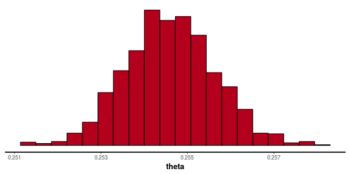

```r
stan_hist(first_fit, bins=20)
```

## Every pitcher is the same

```r
pos_model <- "
data {
    int N;
    int hits[N];
    int at_bats[N];
    int npos; // number of positions
    int position[N];
}
parameters {
    real<lower=0, upper=1> theta[npos];
}
model {
    real theta_vec[N];
    for (k in 1:N) {
        theta_vec[k] = theta[position[k]];
    }
    hits ~ binomial(at_bats, theta_vec);
    theta ~ beta(1, 1);
} "
pos_fit <- stan(model_code=pos_model, chains=3, iter=1000,
                  data=list(N=nrow(batting),
                            hits=batting$Hits,
                            at_bats=batting$AtBats,
                            npos=nlevels(batting$PriPos),
                            position=as.numeric(batting$PriPos)))
```

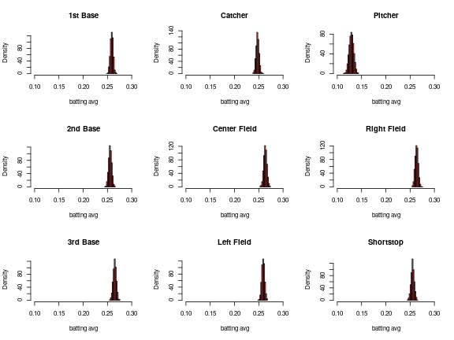

```r
theta_samples <- extract(pos_fit)$theta
layout(matrix(1:9, nrow=3))
for (k in 1:ncol(theta_samples)) {
    hist(theta_samples[,k], main=levels(batting$PriPos)[k], xlim=c(0.1, 0.3),
         col=adjustcolor('red',0.6), xlab='batting avg', freq=FALSE)
}
```

## Your turn : Every individual different.

$$\begin{aligned}
Z_i &\sim \Binom(N_i, \theta_i) \\
\theta_i &\sim \Beta(\alpha_{p_i}, \beta_{p_i}) \\
\alpha_p &= \mu_p \kappa_p \\
\beta_p &= (1-\mu_p) \kappa_p \\
\mu_p &\sim \Beta(1, 1) \\
\kappa_p &\sim \Gam(0.1, 0.1) .
\end{aligned}$$

Variable types in Stan:

```
int x;       // an integer
int y[10];   // ten integers
real z;      // a number
real z[2,5]; // a 2x5 array of numbers

vector[10] u;      // length 10 vector
matrix[10,10] v;   // 10x10 matrix
vector[10] w[10];  // ten length 10 vectors
```

- don’t forget the `;`
- make sure R types match
- read the error messages

## In class

```r
ind_model <- "
data {
    int N;
    int hits[N];
    int at_bats[N];
    int npos; // number of positions
    int position[N];
}
parameters {
    vector<lower=0, upper=1>[N] theta;
    vector<lower=0, upper=1>[npos] mu;
    vector<lower=0>[npos] kappa;
}
model {
    vector[npos] alpha;
    vector[N] alpha_vec;
    vector[npos] beta;
    vector[N] beta_vec;
    alpha = mu .* kappa;
    beta = (1-mu) .* kappa;
    alpha_vec = alpha[position];
    beta_vec = beta[position];
    hits ~ binomial(at_bats, theta);
    theta ~ beta(alpha_vec, beta_vec);
    mu ~ beta(1, 1);
    kappa ~ gamma(0.1, 0.1);
} "
# ind_model <- stan_model(model_code=ind_model)
# ind_fit <- sampling(ind_model,
#                    data=list(
#                              ))
```

# Back to baseball

## The model

$$\begin{aligned}
Z_i &\sim \Binom(N_i, \theta_i) \\
\theta_i &\sim \Beta(\mu_{p_i} \kappa_{p_i}, (1-\mu_{p_i})\kappa_{p_i}) \\
\mu &\sim \Beta(1, 1) \\
\kappa_p &\sim \Gam(0.1, 0.1) .
\end{aligned}$$

```r
pos_model <- "
data {
    int N;   // number of players
    int hits[N];
    int at_bats[N];
    int npos; // number of positions
    int position[N];
}
parameters {
    real<lower=0, upper=1> theta[N];
    real<lower=0, upper=1> mu[npos];
    real<lower=0> kappa[npos];
}
model {
    real alpha;
    real beta;
    hits ~ binomial(at_bats, theta);
    for (i in 1:N) {
        alpha = mu[position[i]] * kappa[position[i]];
        beta = (1 - mu[position[i]]) * kappa[position[i]];
        theta[i] ~ beta(alpha, beta);
    }
    mu ~ beta(1,1);
    kappa ~ gamma(0.1,0.1);
}"
```

```r
batting <- read.csv("BattingAverage.csv", header=TRUE)
system.time(pos_fit <- stan(model_code=pos_model, chains=3, iter=100,
                            data=list(N=nrow(batting),
                                      hits=batting$Hits,
                                      at_bats=batting$AtBats,
                                      npos=nlevels(batting$PriPos),
                                      position=as.numeric(batting$PriPos))))
```

```
##    user  system elapsed
## 112.200   2.931 108.126
```

## Diagnostics

```r
print(pos_fit, pars=c("mu", "kappa"))
```

```
## Inference for Stan model: db775bca82d7fc39d379745fb39b0819.
## 3 chains, each with iter=100; warmup=50; thin=1;
## post-warmup draws per chain=50, total post-warmup draws=150.
##
##            mean se_mean    sd  2.5%    25%    50%    75%  97.5% n_eff Rhat
## mu[1]      0.25    0.00  0.01  0.24   0.25   0.25   0.26   0.26   160 0.99
## mu[2]      0.25    0.00  0.01  0.24   0.24   0.25   0.25   0.26   116 1.02
## mu[3]      0.26    0.00  0.01  0.24   0.25   0.26   0.26   0.27    60 1.04
## mu[4]      0.24    0.00  0.01  0.23   0.24   0.24   0.24   0.25   116 1.01
## mu[5]      0.26    0.00  0.01  0.25   0.25   0.26   0.26   0.27   158 1.00
## mu[6]      0.25    0.00  0.01  0.24   0.25   0.25   0.25   0.26   231 1.00
## mu[7]      0.13    0.00  0.01  0.12   0.13   0.13   0.13   0.14    59 1.00
## mu[8]      0.26    0.00  0.01  0.25   0.25   0.26   0.26   0.27   161 1.00
## mu[9]      0.25    0.00  0.01  0.23   0.24   0.25   0.25   0.26   137 1.00
## kappa[1] 109.81    2.49 23.55 69.93  93.60 106.46 123.82 162.69    89 1.01
## kappa[2] 104.26    1.74 21.84 72.03  88.34 102.28 116.02 154.75   158 1.00
## kappa[3]  96.62    1.74 19.94 64.93  82.89  93.66 110.16 145.40   132 1.00
## kappa[4]  97.03    2.66 18.29 63.37  84.76  94.68 108.26 135.40    47 1.06
## kappa[5] 103.86    2.70 23.51 66.72  87.91 103.24 115.75 162.92    76 1.01
## kappa[6] 108.83    2.37 21.57 70.23  93.81 107.52 121.90 154.71    83 1.00
## kappa[7]  54.77    6.40 13.84 32.39  44.14  54.55  63.40  84.23     5 1.34
## kappa[8] 123.79    2.61 27.30 82.97 104.22 120.78 140.10 187.66   110 1.01
## kappa[9]  97.77    1.71 20.98 61.09  82.47  97.73 109.82 137.03   150 0.99
##
## Samples were drawn using NUTS(diag_e) at Thu Nov 14 09:28:17 2019.
## For each parameter, n_eff is a crude measure of effective sample size,
## and Rhat is the potential scale reduction factor on split chains (at
## convergence, Rhat=1).
```

Is it mixing?

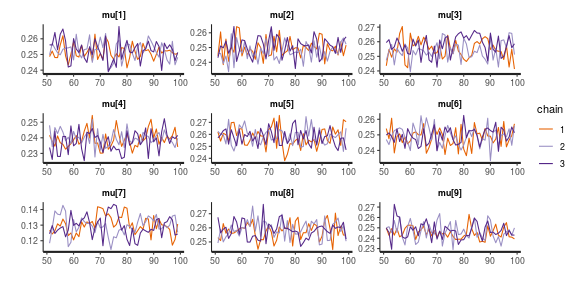

```r
stan_trace(pos_fit, pars="mu")
```

## Run longer!

```r
system.time(pos_fit <- stan(model_code=pos_model, chains=3, iter=1000,
                            control=list(max_treedepth=15),
                            data=list(N=nrow(batting),
                                      hits=batting$Hits,
                                      at_bats=batting$AtBats,
                                      npos=nlevels(batting$PriPos),
                                      position=as.numeric(batting$PriPos))))
```

```
## recompiling to avoid crashing R session
```

```
##     user   system  elapsed
## 1099.156    2.965  535.504
```

```r
print(pos_fit, pars=c("mu", "kappa"))
```

```
## Inference for Stan model: db775bca82d7fc39d379745fb39b0819.
## 3 chains, each with iter=1000; warmup=500; thin=1;
## post-warmup draws per chain=500, total post-warmup draws=1500.
##
##            mean se_mean    sd  2.5%   25%    50%    75%  97.5% n_eff Rhat
## mu[1]      0.25    0.00  0.01  0.24  0.25   0.25   0.26   0.26  1110 1.00
## mu[2]      0.25    0.00  0.01  0.24  0.24   0.25   0.25   0.26  1030 1.00
## mu[3]      0.26    0.00  0.01  0.24  0.25   0.26   0.26   0.27  1095 1.00
## mu[4]      0.24    0.00  0.01  0.23  0.24   0.24   0.24   0.25   935 1.00
## mu[5]      0.26    0.00  0.01  0.24  0.25   0.26   0.26   0.27  1032 1.00
## mu[6]      0.25    0.00  0.01  0.24  0.25   0.25   0.25   0.26   912 1.00
## mu[7]      0.13    0.00  0.01  0.12  0.12   0.13   0.13   0.14   239 1.00
## mu[8]      0.26    0.00  0.01  0.25  0.25   0.26   0.26   0.27  1116 1.00
## mu[9]      0.25    0.00  0.01  0.23  0.24   0.25   0.25   0.26  1144 1.00
## kappa[1] 110.61    0.73 22.33 72.48 94.97 108.77 123.51 159.60   930 1.00
## kappa[2] 105.84    1.02 23.97 66.36 88.65 103.45 119.66 160.69   555 1.01
## kappa[3]  98.04    0.69 21.60 62.37 82.70  95.80 110.93 147.55   968 1.00
## kappa[4]  94.23    0.77 19.24 59.56 80.58  92.43 106.35 135.62   620 1.00
## kappa[5] 101.32    0.77 23.37 61.50 85.42  99.19 115.20 153.30   914 1.00
## kappa[6] 108.69    0.93 23.20 71.92 91.83 105.89 123.72 158.34   620 1.00
## kappa[7]  57.00    2.20 15.76 34.11 45.68  54.23  65.65  95.72    52 1.09
## kappa[8] 119.79    0.81 27.49 73.26 99.95 116.87 136.70 181.07  1142 1.00
## kappa[9]  95.20    0.77 22.54 56.01 79.35  93.30 109.22 144.61   861 1.00
##
## Samples were drawn using NUTS(diag_e) at Thu Nov 14 09:37:18 2019.
## For each parameter, n_eff is a crude measure of effective sample size,
## and Rhat is the potential scale reduction factor on split chains (at
## convergence, Rhat=1).
```

Is it mixing?

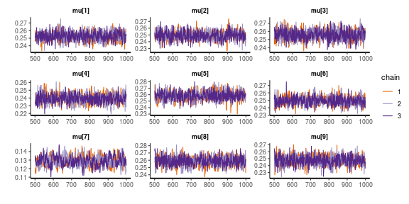

```r
stan_trace(pos_fit, pars="mu")
```

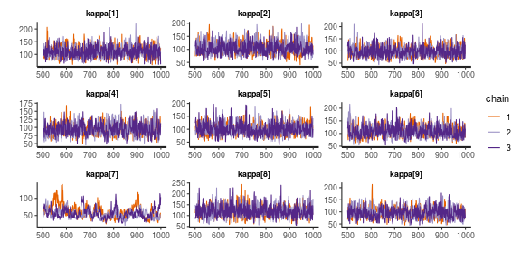

```r
stan_trace(pos_fit, pars="kappa")
```

## Let’s look at the results!

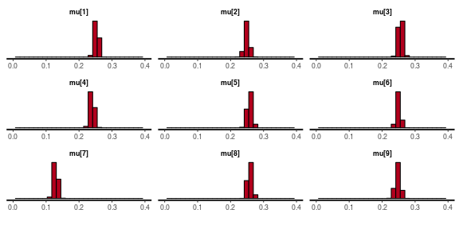

```r
stan_hist(pos_fit, pars="mu", bins=30) + xlim(0, 0.4)
```

With labels: position means $\mu_p$:

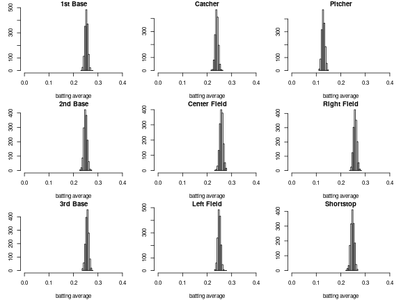

Position “concentrations”, $\kappa_p$:

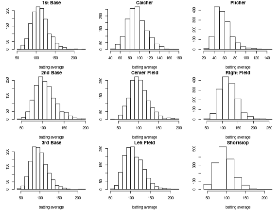